# Deskriptive Datenanalyse mit Pandas und Python

### Daten aus der CSV-Datei lesen

Nun benutzen wir pandas um die CSV-Datei) einzulesen. Damit das funktioniert muss vorher noch das pandas-Paket mit dem `import`-Befehl unter dem Namen `pd` verfügbar gemacht werden.

Dabei wird ein sogenannter [DataFrame](https://pandas.pydata.org/docs/reference/api/pandas.DataFrame.html) mit dem Namen `nba` erzeugt. Vereinfacht kann man sich darunter eine Tabelle mit Spalten und Zeilen vorstellen. DataFrames sind **die** zentralen Datentypen in pandas.

Mit dem Befehl `type()` kann der Datentyp eines jeden Python-Objekts ausgegeben werden.

```python
import pandas as pd
import matplotlib.pyplot as plt
nba = pd.read_csv("nba_all_elo.csv")
type(nba)
pd.set_option("display.max.columns", None)
# Expected:
# <class 'pandas.core.frame.DataFrame'>
```

```python
nba.tail(20)
```

|  | gameorder | game_id | lg_id | _iscopy | year_id | date_game | seasongame | is_playoffs | team_id | fran_id | pts | elo_i | elo_n | win_equiv | opp_id | opp_fran | opp_pts | opp_elo_i | opp_elo_n | game_location | game_result | forecast | notes | difference |
| --- | --- | --- | --- | --- | --- | --- | --- | --- | --- | --- | --- | --- | --- | --- | --- | --- | --- | --- | --- | --- | --- | --- | --- | --- |
| 126294 | 63148 | 201505240CLE | NBA | 0 | 2015 | 5/24/2015 | 95 | 1 | CLE | Cavaliers | 114 | 1701.5128 | 1703.7124 | 60.254032 | ATL | Hawks | 111 | 1591.4017 | 1589.2021 | H | W | 0.770210 | NaN | 3 |
| 126295 | 63148 | 201505240CLE | NBA | 1 | 2015 | 5/24/2015 | 97 | 1 | ATL | Hawks | 111 | 1591.4017 | 1589.2021 | 49.744450 | CLE | Cavaliers | 114 | 1701.5128 | 1703.7124 | A | L | 0.229790 | NaN | -3 |
| 126296 | 63149 | 201505250HOU | NBA | 1 | 2015 | 5/25/2015 | 96 | 1 | GSW | Warriors | 115 | 1813.4543 | 1797.8933 | 67.053963 | HOU | Rockets | 128 | 1643.4324 | 1658.9934 | A | L | 0.599427 | NaN | -13 |
| 126297 | 63149 | 201505250HOU | NBA | 0 | 2015 | 5/25/2015 | 98 | 1 | HOU | Rockets | 128 | 1643.4324 | 1658.9934 | 56.407814 | GSW | Warriors | 115 | 1813.4543 | 1797.8933 | H | W | 0.400573 | NaN | 13 |
| 126298 | 63150 | 201505260CLE | NBA | 0 | 2015 | 5/26/2015 | 96 | 1 | CLE | Cavaliers | 118 | 1703.7124 | 1712.1232 | 60.934734 | ATL | Hawks | 88 | 1589.2021 | 1580.7914 | H | W | 0.774661 | NaN | 30 |
| 126299 | 63150 | 201505260CLE | NBA | 1 | 2015 | 5/26/2015 | 98 | 1 | ATL | Hawks | 88 | 1589.2021 | 1580.7914 | 48.898579 | CLE | Cavaliers | 118 | 1703.7124 | 1712.1232 | A | L | 0.225339 | NaN | -30 |
| 126300 | 63151 | 201505270GSW | NBA | 1 | 2015 | 5/27/2015 | 99 | 1 | HOU | Rockets | 90 | 1658.9934 | 1654.6359 | 56.013645 | GSW | Warriors | 104 | 1797.8933 | 1802.2509 | A | L | 0.201778 | NaN | -14 |
| 126301 | 63151 | 201505270GSW | NBA | 0 | 2015 | 5/27/2015 | 97 | 1 | GSW | Warriors | 104 | 1797.8933 | 1802.2509 | 67.324539 | HOU | Rockets | 90 | 1658.9934 | 1654.6359 | H | W | 0.798222 | NaN | 14 |
| 126302 | 63152 | 201506040GSW | NBA | 1 | 2015 | 6/4/2015 | 97 | 1 | CLE | Cavaliers | 100 | 1712.1232 | 1708.1705 | 60.616585 | GSW | Warriors | 108 | 1802.2509 | 1806.2035 | A | L | 0.250779 | NaN | -8 |
| 126303 | 63152 | 201506040GSW | NBA | 0 | 2015 | 6/4/2015 | 98 | 1 | GSW | Warriors | 108 | 1802.2509 | 1806.2035 | 67.566650 | CLE | Cavaliers | 100 | 1712.1232 | 1708.1705 | H | W | 0.749221 | NaN | 8 |
| 126304 | 63153 | 201506070GSW | NBA | 1 | 2015 | 6/7/2015 | 98 | 1 | CLE | Cavaliers | 95 | 1708.1705 | 1716.8708 | 61.312763 | GSW | Warriors | 93 | 1806.2035 | 1797.5032 | A | W | 0.242326 | NaN | 2 |
| 126305 | 63153 | 201506070GSW | NBA | 0 | 2015 | 6/7/2015 | 99 | 1 | GSW | Warriors | 93 | 1806.2035 | 1797.5032 | 67.029549 | CLE | Cavaliers | 95 | 1708.1705 | 1716.8708 | H | L | 0.757674 | NaN | -2 |
| 126306 | 63154 | 201506090CLE | NBA | 1 | 2015 | 6/9/2015 | 100 | 1 | GSW | Warriors | 91 | 1797.5032 | 1790.9591 | 66.615417 | CLE | Cavaliers | 96 | 1716.8708 | 1723.4149 | A | L | 0.472157 | NaN | -5 |
| 126307 | 63154 | 201506090CLE | NBA | 0 | 2015 | 6/9/2015 | 99 | 1 | CLE | Cavaliers | 96 | 1716.8708 | 1723.4149 | 61.826408 | GSW | Warriors | 91 | 1797.5032 | 1790.9591 | H | W | 0.527843 | NaN | 5 |
| 126308 | 63155 | 201506110CLE | NBA | 1 | 2015 | 6/11/2015 | 101 | 1 | GSW | Warriors | 103 | 1790.9591 | 1809.9791 | 67.794983 | CLE | Cavaliers | 82 | 1723.4149 | 1704.3949 | A | W | 0.453428 | NaN | 21 |
| 126309 | 63155 | 201506110CLE | NBA | 0 | 2015 | 6/11/2015 | 100 | 1 | CLE | Cavaliers | 82 | 1723.4149 | 1704.3949 | 60.309792 | GSW | Warriors | 103 | 1790.9591 | 1809.9791 | H | L | 0.546572 | NaN | -21 |
| 126310 | 63156 | 201506140GSW | NBA | 0 | 2015 | 6/14/2015 | 102 | 1 | GSW | Warriors | 104 | 1809.9791 | 1813.6349 | 68.013329 | CLE | Cavaliers | 91 | 1704.3949 | 1700.7391 | H | W | 0.765565 | NaN | 13 |
| 126311 | 63156 | 201506140GSW | NBA | 1 | 2015 | 6/14/2015 | 101 | 1 | CLE | Cavaliers | 91 | 1704.3949 | 1700.7391 | 60.010067 | GSW | Warriors | 104 | 1809.9791 | 1813.6349 | A | L | 0.234435 | NaN | -13 |
| 126312 | 63157 | 201506170CLE | NBA | 0 | 2015 | 6/16/2015 | 102 | 1 | CLE | Cavaliers | 97 | 1700.7391 | 1692.0859 | 59.290245 | GSW | Warriors | 105 | 1813.6349 | 1822.2881 | H | L | 0.481450 | NaN | -8 |
| 126313 | 63157 | 201506170CLE | NBA | 1 | 2015 | 6/16/2015 | 103 | 1 | GSW | Warriors | 105 | 1813.6349 | 1822.2881 | 68.519516 | CLE | Cavaliers | 97 | 1700.7391 | 1692.0859 | A | W | 0.518550 | NaN | 8 |

# Aufgaben

1) In wie vielen Spielen erzielte eine der Mannschaften weniger als 50 Punkte? In wie vielen mehr als 150 Punkte? 2) Geben Sie die Zeile (= das Spiel) aus, bei dem die höchste je erzielte Punktzahl erreicht wurde. 3) Wie viele Spiele haben die Boston Celtics (`team_id` = BOS) im gesamten Zeitraum gespielt? 4) Wie viele Punkte erzielten die Golden State Warriors (`team_id`= GSW) im Schnitt (=arithmetisches Mittel) im gesamten Zeitraum? Wie viele im Zeitraum seit dem Jahr 2000? 5) Erzeugen Sie Boxplots für beide Fragestellungen aus Aufgabe 4). 6) Wie hat sich die Anzahl der Punkte pro Spiel über die Jahre geändert? Erstellen Sie eine geeignete Visualisierung. 7) Erzeugen Sie die neue Spalte `difference` im DataFrame nba. Diese soll die Differenz zwischen der Spalte `pts`und der Spalte `opp_pts` enthalten. Visualisieren Sie die Häufigkeitsverteilung der Punktedifferenzen der Spiele (ohne Kopien -> `is_copy == 0`) mit einem Histogram. 8) Betrachten Sie die mit seaborn erzeugten Plots unten. Was sehen Sie in den einzelnen Darstellungen? Welche Schlüsse können Sie daraus ggf. ziehen? Passen Sie Filter und Darstellung nach ihren Wünschen an. Achtung: Die Spalte `difference` aus Aufgabe 7) kann erst visualisiert werden, sobald sie Teil des DataFrame `nba` ist. Weitere Beispiele und Dokumentation finden Sie unter https://seaborn.pydata.org/index.html

```python
import seaborn as sns

sns.set_style("whitegrid")
```

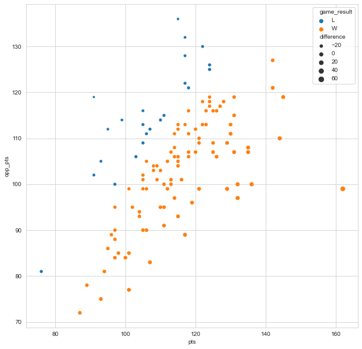

```python
#8.1
plt.figure(figsize=(10,10))
sns.scatterplot(data=nba[(nba["_iscopy"]==0)& ((nba["team_id"]=="LAL") & (nba["opp_id"]== "GSW"))], x="pts", y="opp_pts", hue="game_result", size="difference")
```

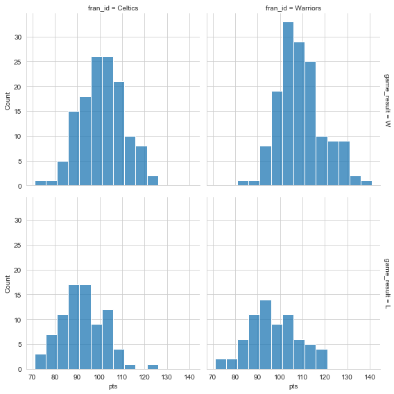

```python
#8.2
sns.displot(
    nba[(nba["_iscopy"]==0)&(nba["year_id"]>2010) & ((nba["team_id"]=="GSW") | (nba["team_id"]== "BOS"))], x="pts", col="fran_id", row="game_result",
    binwidth=5, height=4, facet_kws=dict(margin_titles=True),
)
```

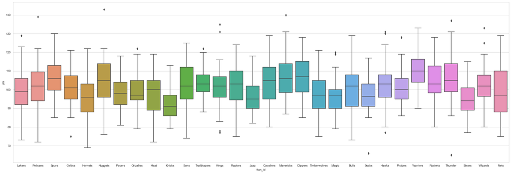

```python
#8.3
plt.figure(figsize=(30,10))
ax = sns.boxplot(data=nba[(nba["_iscopy"]==0)&(nba["year_id"]==2015)], x="fran_id", y="pts")

#Die Zeile unterhalb können Sie aktivieren in dem Sie das #-Zeichen löschen. Nun werden die einzelnen Werte als Punkte auf die Boxplots gelegt.
#ax = sns.swarmplot(data=nba[(nba["_iscopy"]==0)&(nba["year_id"]==2015)], x="fran_id", y="pts", color = "0.25")
```

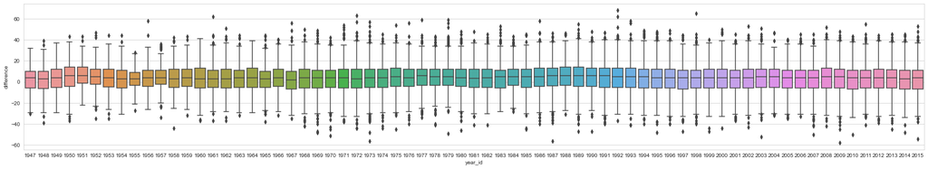

```python
#8.4
plt.figure(figsize=(30,5))
sns.boxplot(data=nba[nba["_iscopy"]==0], x="year_id", y="difference")
```

## Lösung:

### Teilaufgabe 1

In wie vielen Spielen erzielte eine der Mannschaften weniger als 50 Punkte? In wie vielen mehr als 150 Punkte?

```python
nba[(nba["pts"]>150) | (nba["pts"]<50)]
```

|  | gameorder | game_id | lg_id | _iscopy | year_id | date_game | seasongame | is_playoffs | team_id | fran_id | pts | elo_i | elo_n | win_equiv | opp_id | opp_fran | opp_pts | opp_elo_i | opp_elo_n | game_location | game_result | forecast | notes |
| --- | --- | --- | --- | --- | --- | --- | --- | --- | --- | --- | --- | --- | --- | --- | --- | --- | --- | --- | --- | --- | --- | --- | --- |
| 3 | 2 | 194611020CHS | NBA | 1 | 1947 | 11/2/1946 | 2 | 0 | NYK | Knicks | 47 | 1306.7233 | 1297.0712 | 40.692783 | CHS | Stags | 63 | 1300.0000 | 1309.6521 | A | L | 0.368899 | NaN |
| 4 | 3 | 194611020DTF | NBA | 0 | 1947 | 11/2/1946 | 1 | 0 | DTF | Falcons | 33 | 1300.0000 | 1279.6189 | 38.864048 | WSC | Capitols | 50 | 1300.0000 | 1320.3811 | H | L | 0.640065 | NaN |
| 17 | 9 | 194611050DTF | NBA | 0 | 1947 | 11/5/1946 | 2 | 0 | DTF | Falcons | 49 | 1279.6189 | 1271.4624 | 38.011841 | STB | Bombers | 53 | 1304.6908 | 1312.8473 | H | L | 0.606189 | NaN |
| 28 | 15 | 194611090DTF | NBA | 1 | 1947 | 11/9/1946 | 3 | 0 | BOS | Celtics | 46 | 1288.4139 | 1275.2767 | 38.410091 | DTF | Falcons | 69 | 1268.4468 | 1281.5840 | A | L | 0.386818 | NaN |
| 50 | 26 | 194611160BOS | NBA | 1 | 1947 | 11/16/1946 | 6 | 0 | TRH | Huskies | 49 | 1294.7554 | 1290.0051 | 39.951809 | BOS | Celtics | 53 | 1267.1501 | 1271.9004 | A | L | 0.397298 | NaN |
| ... | ... | ... | ... | ... | ... | ... | ... | ... | ... | ... | ... | ... | ... | ... | ... | ... | ... | ... | ... | ... | ... | ... | ... |
| 107739 | 53870 | 200803160DEN | NBA | 0 | 2008 | 3/16/2008 | 66 | 0 | DEN | Nuggets | 168 | 1593.9622 | 1598.6810 | 50.984306 | SEA | Thunder | 116 | 1300.8906 | 1296.1718 | H | W | 0.905741 | NaN |
| 108072 | 54037 | 200804060SEA | NBA | 0 | 2008 | 4/6/2008 | 77 | 0 | SEA | Thunder | 151 | 1263.7084 | 1276.4270 | 19.691620 | DEN | Nuggets | 147 | 1611.4169 | 1598.6982 | H | W | 0.193734 | NaN |
| 108174 | 54088 | 200804140MIL | NBA | 1 | 2008 | 4/14/2008 | 81 | 0 | CHI | Bulls | 151 | 1409.0687 | 1422.5135 | 32.820984 | MIL | Bucks | 135 | 1297.0819 | 1283.6371 | A | W | 0.517244 | NaN |
| 110376 | 55189 | 200903150GSW | NBA | 1 | 2009 | 3/15/2009 | 67 | 0 | PHO | Suns | 154 | 1524.2294 | 1544.7966 | 45.428856 | GSW | Warriors | 130 | 1452.0404 | 1431.4731 | A | W | 0.460062 | NaN |
| 113037 | 56519 | 201003160PHO | NBA | 0 | 2010 | 3/16/2010 | 68 | 0 | PHO | Suns | 152 | 1585.8059 | 1589.3263 | 49.905102 | MIN | Timberwolves | 114 | 1282.7975 | 1279.2771 | H | W | 0.910512 | NaN |

220 rows × 23 columns

```python
nba[(nba["pts"]>150)].game_id.count()
```

```
159
```

```python
nba[(nba["pts"]<50)].game_id.count()
```

```
61
```

Achtung! Spiele können bei der obigen Abfrage zweimal gezählt werden (beide Mannschaften erzielen < 50 bzw. > 150), da Spiele bekanntlich aus Sicht beider Mannschaften aufgeführt sind.

Eine Alternative wäre (mit Abfrage des Feldes `_iscopy`):

```python
#Spieleliste:
nba[ (nba["_iscopy"] == 0) &
( (nba["pts"]>150) | (nba["pts"]<50) |(nba["opp_pts"]>150) | (nba["opp_pts"]<50) ) ]
```

|  | gameorder | game_id | lg_id | _iscopy | year_id | date_game | seasongame | is_playoffs | team_id | fran_id | pts | elo_i | elo_n | win_equiv | opp_id | opp_fran | opp_pts | opp_elo_i | opp_elo_n | game_location | game_result | forecast | notes |
| --- | --- | --- | --- | --- | --- | --- | --- | --- | --- | --- | --- | --- | --- | --- | --- | --- | --- | --- | --- | --- | --- | --- | --- |
| 2 | 2 | 194611020CHS | NBA | 0 | 1947 | 11/2/1946 | 1 | 0 | CHS | Stags | 63 | 1300.0000 | 1309.6521 | 42.012257 | NYK | Knicks | 47 | 1306.7233 | 1297.0712 | H | W | 0.631101 | NaN |
| 4 | 3 | 194611020DTF | NBA | 0 | 1947 | 11/2/1946 | 1 | 0 | DTF | Falcons | 33 | 1300.0000 | 1279.6189 | 38.864048 | WSC | Capitols | 50 | 1300.0000 | 1320.3811 | H | L | 0.640065 | NaN |
| 17 | 9 | 194611050DTF | NBA | 0 | 1947 | 11/5/1946 | 2 | 0 | DTF | Falcons | 49 | 1279.6189 | 1271.4624 | 38.011841 | STB | Bombers | 53 | 1304.6908 | 1312.8473 | H | L | 0.606189 | NaN |
| 29 | 15 | 194611090DTF | NBA | 0 | 1947 | 11/9/1946 | 4 | 0 | DTF | Falcons | 69 | 1268.4468 | 1281.5840 | 39.069672 | BOS | Celtics | 46 | 1288.4139 | 1275.2767 | H | W | 0.613182 | NaN |
| 51 | 26 | 194611160BOS | NBA | 0 | 1947 | 11/16/1946 | 6 | 0 | BOS | Celtics | 53 | 1267.1501 | 1271.9004 | 38.057545 | TRH | Huskies | 49 | 1294.7554 | 1290.0051 | H | W | 0.602702 | NaN |
| ... | ... | ... | ... | ... | ... | ... | ... | ... | ... | ... | ... | ... | ... | ... | ... | ... | ... | ... | ... | ... | ... | ... | ... |
| 107739 | 53870 | 200803160DEN | NBA | 0 | 2008 | 3/16/2008 | 66 | 0 | DEN | Nuggets | 168 | 1593.9622 | 1598.6810 | 50.984306 | SEA | Thunder | 116 | 1300.8906 | 1296.1718 | H | W | 0.905741 | NaN |
| 108072 | 54037 | 200804060SEA | NBA | 0 | 2008 | 4/6/2008 | 77 | 0 | SEA | Thunder | 151 | 1263.7084 | 1276.4270 | 19.691620 | DEN | Nuggets | 147 | 1611.4169 | 1598.6982 | H | W | 0.193734 | NaN |
| 108175 | 54088 | 200804140MIL | NBA | 0 | 2008 | 4/14/2008 | 81 | 0 | MIL | Bucks | 135 | 1297.0819 | 1283.6371 | 20.248922 | CHI | Bulls | 151 | 1409.0687 | 1422.5135 | H | L | 0.482756 | NaN |
| 110377 | 55189 | 200903150GSW | NBA | 0 | 2009 | 3/15/2009 | 66 | 0 | GSW | Warriors | 130 | 1452.0404 | 1431.4731 | 33.639706 | PHO | Suns | 154 | 1524.2294 | 1544.7966 | H | L | 0.539938 | NaN |
| 113037 | 56519 | 201003160PHO | NBA | 0 | 2010 | 3/16/2010 | 68 | 0 | PHO | Suns | 152 | 1585.8059 | 1589.3263 | 49.905102 | MIN | Timberwolves | 114 | 1282.7975 | 1279.2771 | H | W | 0.910512 | NaN |

195 rows × 23 columns

```python
#Anzahl:
nba[(nba["_iscopy"] == 0) & ((nba["pts"]>150)| (nba["opp_pts"]>150))].game_id.count()
```

```
142
```

```python
#Anzahl
nba[(nba["_iscopy"] == 0) & ((nba["pts"]<50)| (nba["opp_pts"]<50))].game_id.count()
```

```
53
```

### Teilaufgabe 2

Geben Sie die Zeile (= das Spiel) aus, bei dem die höchste je erzielte Punktzahl erreicht wurde.

```python
nba.loc[nba["pts"].idxmax()]
```

|  | gameorder | game_id | lg_id | _iscopy | year_id | date_game | seasongame | is_playoffs | team_id | fran_id | pts | elo_i | elo_n | win_equiv | opp_id | opp_fran | opp_pts | opp_elo_i | opp_elo_n | game_location | game_result | forecast | notes |
| --- | --- | --- | --- | --- | --- | --- | --- | --- | --- | --- | --- | --- | --- | --- | --- | --- | --- | --- | --- | --- | --- | --- | --- |
| 50094 | 25048 | 198312130DEN | NBA | 1 | 1984 | 12/13/1983 | 23 | 0 | DET | Pistons | 186 | 1491.8865 | 1499.0237 | 40.800941 | DEN | Nuggets | 184 | 1512.6967 | 1505.5594 | A | W | 0.332824 | NaN |

### Teilaufgabe 3

Wie viele Spiele haben die Boston Celtics (`team_id` = BOS) im gesamten Zeitraum gespielt?

```python
nba.loc[nba["team_id"]=="BOS", "team_id"].count()
```

```
5997
```

### Teilaufgabe 4

Wie viele Punkte erzielten die Golden State Warriors (`team_id`= GSW) im Schnitt (=arithmetisches Mittel) im gesamten Zeitraum? Wie viele im Zeitraum seit dem Jahr 2000?

```python
nba[nba["team_id"]=="GSW"].pts.mean()
```

```
105.92461496892732
```

```python
nba[(nba["team_id"]=="GSW") &
(nba["year_id"]>=2000)
].pts.mean()
```

```
104.37790697674419
```

### Teilaufgabe 5

Erzeugen Sie Boxplots für beide Fragestellungen aus Aufgabe 4).

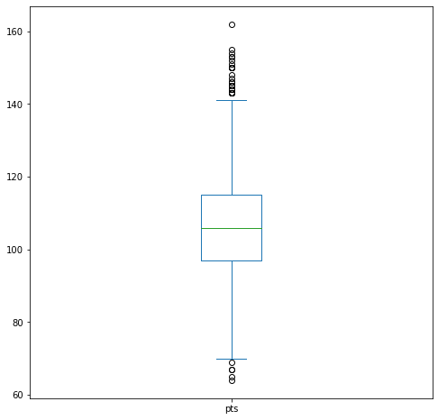

```python
nba[nba["team_id"]=="GSW"].pts.plot(kind="box", figsize=(8,8))
```

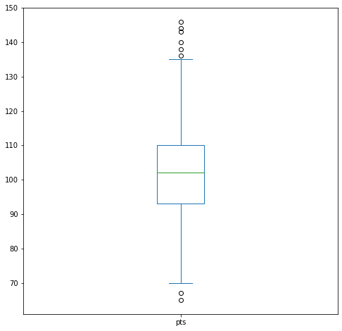

```python
nba[(nba["team_id"]=="GSW") &
(nba["year_id"]>=2000)
].pts.plot(kind="box", figsize=(8,8))
```

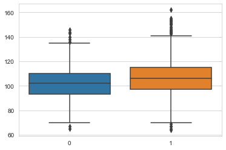

```python
import seaborn as sns

sns.set_style("whitegrid")
two_series = [nba[(nba["team_id"]=="GSW") & (nba["year_id"]>=2000)].loc[:,"pts"], nba[(nba["team_id"]=="GSW")].loc[:,"pts"] ]
sns.boxplot(data=two_series)
```

### Teilaufgabe 6

Wie hat sich die Anzahl der Punkte pro Spiel über die Jahre geändert? Erstellen Sie eine geeignete Visualisierung.

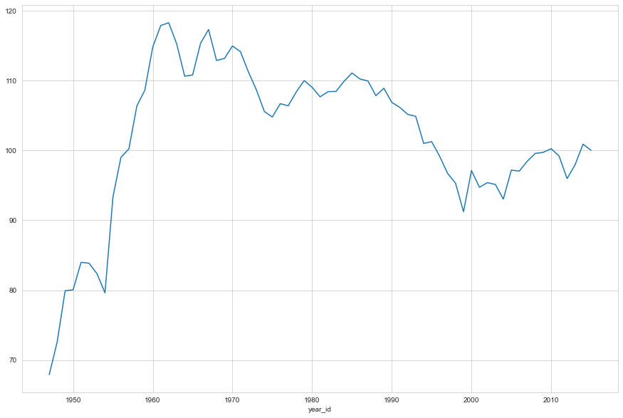

```python
nba.groupby("year_id", sort=False)["pts"].mean().plot(figsize=(15,10))
```

### Teilaufgabe 7

Erzeugen Sie die neue Spalte `difference` im DataFrame nba. Diese soll die Differenz zwischen der Spalte `pts`und der Spalte `opp_pts` enthalten. Visualisieren Sie die Häufigkeitsverteilung der Punktedifferenzen der Spiele (ohne Kopien -> `is_copy == 0`) mit einem Histogram.

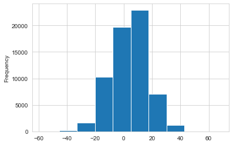

```python
nba["difference"] = nba.pts - nba.opp_pts
nba[nba["_iscopy"]==0].difference.plot(kind="hist")
```